# Tutorial 6 - Exploring statistical relationships

### **Quick links**

1. Power Analyses
2. Visualising and Conducting Correlations
3. Linear Regressions

### **Checking installation and loading packages**

As usual we first always check and load in our required packages.

```r
# Check if packages are installed, if not install.
if(!require(here)) install.packages('here') #checks if a package is installed and installs it if required.
if(!require(tidyverse)) install.packages('tidyverse')
if(!require(ggplot2)) install.packages('ggplot2')

library(here) #loads in the specified package
library(tidyverse)
library(ggplot2)
```

### **Activity 1 - Installing and loading a new package**

We are going to be using a new package called `pwrss`. This will allow us to complete power calculations.

Can you figure out how to check if this package is already installed on your computer and get it up and loaded ?

```r
if(!require(pwrss)) install.packages("pwrss")

library(pwrss)
```

Well done ! If you aren’t able to figure this out please ask your tutor as you will need this package installed to complete todays computing activities.

### **Investigating correlational relationships**

This week, we are going to explore relationships between continuous variables, using correlation and regression.

We have previously looked at how mood and location influence social media use. Now we’re going to look at the relationship between social media use, age and political activism. It has previously been shown that social media use has a positive relationship with levels of political activism in other countries such as Jordan (Alodat et al, 2023). However, we don’t know if this is true for young adults in Australia. This is what we will test today.

### **Activity 2 - Formulate your research question**

Before we being we first need to load in our dataset for today. Are you able to load in the `PSYC2001_social-media-data.csv` dataset ?

```r
social_media <- read.csv(file = here("Data","PSYC2001_social-media-data.csv")) #reads in CSV files
```

Will young adults who spend a lot of time on social media be more policitally active ? Or the opposite? Or neither ?

**Question:** What is a reasonable null and alternate hypothesis? The class will come up with a hypothesis.

### **Power analysis on correlations**

Now that we have generated our hypothesis, **it would be good practice to conduct a power analysis to determine the sample size required to detect our effect of interest.**

When conducting a power analysis for correlations (as should be clear from your lectures and tutorials on power analysis) there are a few important ingredients.

The first is **desired power**. Lets say we want 90% power to detect our effect. The second is the **alpha level**. This is conventionally set to 0.05.

The final is the **correlation coefficient ‘r’**.

**Question:** What do you think the correlation coefficient ‘r’ will be for our class hypothesis?

Now that we have these parameters we can perform a power calculation using the `pwrss.z.corr` function.

```r
pwrss.z.corr(r = 0.60, r0 = 0,
             power = 0.90, alpha = 0.05,
             alternative = "not equal")
```

```
##  A Correlation against a Constant (z Test)
##  H0: r = r0
##  HA: r != r0
##  ------------------------------
##   Statistical power = 0.9
##   n = 25
##  ------------------------------
##  Alternative = "not equal"
##  Non-centrality parameter = 3.242
##  Type I error rate = 0.05
##  Type II error rate = 0.1
```

**Question:** What is the takeaway from this output ? Do we have a sufficient sample size to detect our effect of interest ?

**Info:** We can also use this package to do power calculations for other tests like t-tests and regressions.

### **Activity 3 - Conducting a power analysis for a t-test**

We can also use the power analysis functions from the `pwrss` package to perform power analyses for other types of statistical tests. For instance, we can conduct a power analysis for an independent samples t-test using the function `pwrss.t.2means`.

The below is an example of how this could be input to determine sample size.

```r
pwrss.t.2means(mu1 = 0, mu2 = 25, sd1 = 50, power = 0.90, alpha = 0.05 ) #set mu1 =0 so that mu2 can be the mean difference value. sd1 is the standard deviation.
```

```
##  Difference between Two means
##  (Independent Samples t Test)
##  H0: mu1 = mu2
##  HA: mu1 != mu2
##  ------------------------------
##   Statistical power = 0.9
##   n1 = 86
##   n2 = 86
##  ------------------------------
##  Alternative = "not equal"
##  Degrees of freedom = 170
##  Non-centrality parameter = -3.279
##  Type I error rate = 0.05
##  Type II error rate = 0.1
```

[figure not shown]

Figure 1: The power of power analyses

### **Activity 4 - How much political attitude?**

Let’s now get an idea of our much political attitude these participants have. We have scores from 3 subscales of a political-attitudes questionnaire. We need to combine them into a single ‘attitude’ score for each participant. Each subscale score carries a different weighting towards the total ‘attitude’ score.

**Question:** Why would each subscale carry a different weighting?

The formula for calculating attitude is:

$Attitude = 0.25 \times informed + 0.35 \times campaign + 0.4 \times activism$

Using this formula are you able to figure out how to create the attitude variables ?

**Hint:** Use the mutate function !

```r
social_media_attitutde <- social_media %>%
  mutate(attitude = 0.25*polit_informed +
                    0.35*polit_campaign +
                    0.4*polit_activism)
```

### **Activity 5 - looking for straight lines**

Now lets visualise this in R.

We’re going to explore our data to see if it is suitable for a regression analysis. Remember, we use a regression analysis when we think a straight line is a good enough description of the relationship between our variables.

[figure not shown]

Figure 2: MFW people don’t visualise their data

Let’s use `ggplot` to make scatter plots to show the relationships between age, time_on_social and attitude. You should wind up with 3 scatterplots.

**Hint:** Remember that you need to change `-999` values to `NA` before you can plot!

```r
social_media_attitutde_NA <- social_media_attitutde %>%
  mutate(time_on_social = na_if(time_on_social,-999)) #mutate alters columns and rows.
                                                      #na_if replaces -999 with NA.
```

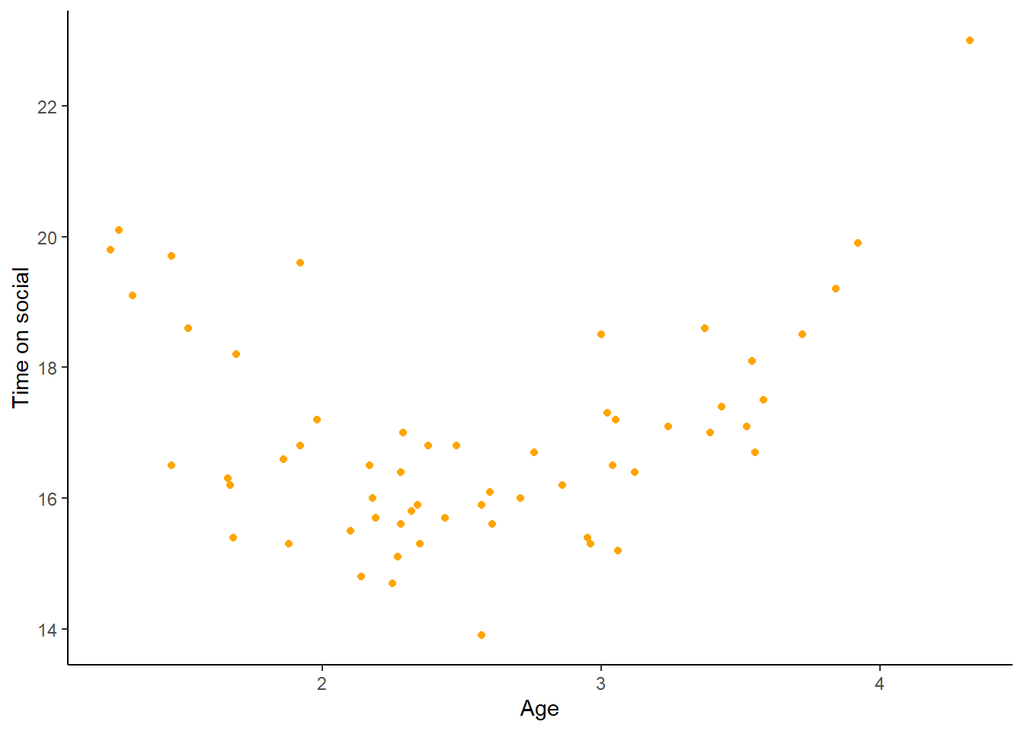

```r
social_media_attitutde_NA %>%
  ggplot(aes(y = age, x = time_on_social)) +
  geom_point(colour = "orange") +
  labs(x = "Age", y = "Time on social") +
  theme_classic()
```

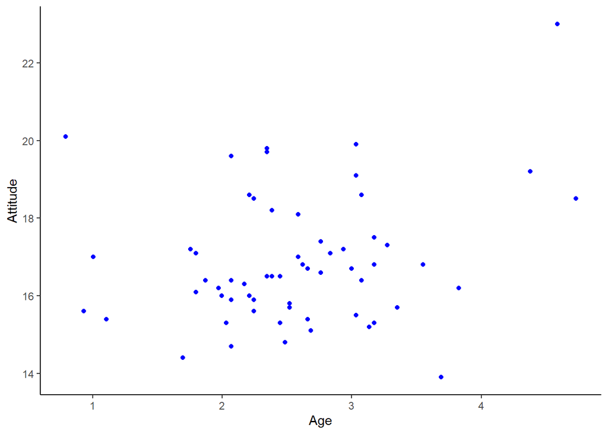

```r
social_media_attitutde_NA %>%
  ggplot(aes(y = age, x = attitude)) +
  geom_point(colour = "blue") +
  labs(x = "Age", y = "Attitude") +
  theme_classic()
```

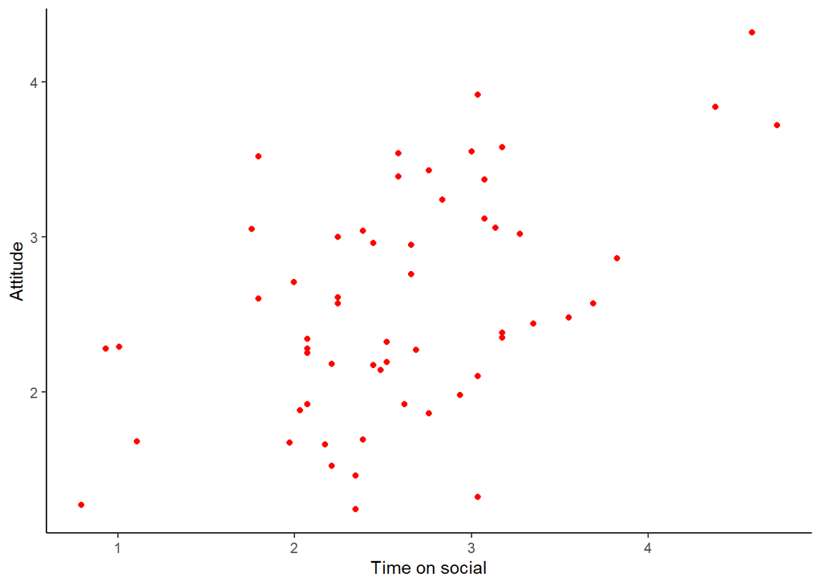

```r
social_media_attitutde_NA %>%
  ggplot(aes(y = time_on_social, x = attitude)) +
  geom_point(colour = "red") +
  labs(x = "Time on social", y = "Attitude") +
  theme_classic()
```

**Question:** Do the relationships look linear or non-linear? Which correlation analyses would you be more cautious about running?